# neale ahmed el-dash - Pesquisa Google

[figure not shown]

Aproximadamente 10.700 resultados (0,66 segundos)

## Resultados da pesquisa

### [Neale Ahmed El-Dash | LinkedIn](https://br.linkedin.com/in/neale/pt)

https://br.linkedin.com/in/**neale**/pt

Campinas, São Paulo, Brazil - Diretor na Ipsos Public Affairs

Visualize o perfil profissional de *Neale Ahmed El-Dash* (Brasil) no LinkedIn. O LinkedIn é a maior rede de negócios do mundo, que ajuda profissionais como ...

### [Neale Ahmed El-Dash | Facebook](https://pt-br.facebook.com/neale.eldash)

https://pt-br.facebook.com/**neale**.**eldash**

- [Em cache](http://webcache.googleusercontent.com/search?q=cache:pnfOWJ2t5F8J:https://pt-br.facebook.com/neale.eldash+&cd=2&hl=pt-BR&ct=clnk&gl=br)

*Neale Ahmed El-Dash* está no Facebook. Participe do Facebook para se conectar com *Neale Ahmed El-Dash* e outros que você talvez conheça. O Facebook ...

### [Polling Data](http://pollingdata.com.br/)

pollingdata.com.br/

- [Em cache](http://webcache.googleusercontent.com/search?q=cache:6Vyw9qcBq9EJ:pollingdata.com.br/+&cd=3&hl=pt-BR&ct=clnk&gl=br)

Sleek Data - Soluções de Inteligência Competitiva.

### [Re: [ABE-L]: Fwd: Estatístico entende de amostra ... - IME-USP](http://www.ime.usp.br/~abe/lista/msg04434.html)

www.ime.usp.br/~abe/lista/msg04434.html

- [Em cache](http://webcache.googleusercontent.com/search?q=cache:19NX7LtucOkJ:www.ime.usp.br/~abe/lista/msg04434.html+&cd=4&hl=pt-BR&ct=clnk&gl=br)

25 de nov de 2009 - *Neale Ahmed El-Dash* Doutorando em Estatística Celular: (11) 96545833. Email: neale.eldash@gmail.com. -- Vermelho F.: (21) 2501 2332 - ...

### [[ABE-L] Fwd: Neale El-Dash lhe enviou um arquivo de ...](https://lists.ime.usp.br/archives/abe/2014-October/000676.html)

https://lists.ime.usp.br/archives/abe/2014-October/000676.html

- [Em cache](http://webcache.googleusercontent.com/search?q=cache:mJ2ahK1LHUAJ:https://lists.ime.usp.br/archives/abe/2014-October/000676.html+&cd=5&hl=pt-BR&ct=clnk&gl=br)

[ABE-L] Fwd: *Neale El*-*Dash* lhe enviou um arquivo de imagem. *Neale El*-*Dash neale*.*eldash* em gmail.com. Domingo Outubro 26 00:21:12 BRST 2014.

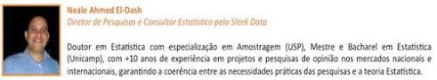

### [PDF][Apresentação Oral - SINAPE 2010 - Neale El-Dash.pdf](http://www.ime.unicamp.br/sinape/sites/default/files/Apresenta%C3%A7%C3%A3o%20Oral%20-%20SINAPE%202010%20-%20Neale%20El-Dash.pdf)

www.ime.unicamp.br/.../Apresentação%20Oral%20-%20SINAPE%2020...

- Em cache

de NA El-Dash-contato - [Artigos relacionados](https://scholar.google.com.br/scholar?gws_rd=cr,ssl&um=1&ie=UTF-8&lr&q=related:r0ywljT0gAGqLM:scholar.google.com/)

Autor: *Neale Ahmed El-Dash* - contato: neale.eldash@gmail.com .... viciado, como pode ser visto em El-Dash [2010], sem esquecer que esse ser o estimador ...

### [Workshop em Análise de Sobrevivência e Aplicações (WASA)](http://www.ime.unicamp.br/~wasa/ListaInscritos.html)

www.ime.unicamp.br/~wasa/ListaInscritos.html

- [Em cache](http://webcache.googleusercontent.com/search?q=cache:W981NWjITr0J:www.ime.unicamp.br/~wasa/ListaInscritos.html+&cd=13&hl=pt-BR&ct=clnk&gl=br)

*Neale Ahmed El Dash*, SLEEK DATA. Clécio da Silva Ferreira, UFJF. Luis E. Benites Sánchez, IMECC/UNICAMP. Adriano Kamimura Suzuki, ICMC-USP.

### [Neale Ahmed El Dash - Records - Ancestry.com](http://records.ancestry.com/neale_ahmed_el_dash_records.ashx?pid=180350354)

records.ancestry.com/**neale**_**ahmed**_**el**_**dash**_records...

- [Em cache](http://webcache.googleusercontent.com/search?q=cache:npKT0Wy2OfoJ:records.ancestry.com/neale_ahmed_el_dash_records.ashx%3Fpid%3D180350354+&cd=14&hl=pt-BR&ct=clnk&gl=br)

[Traduzir esta página](http://translate.google.com.br/translate?hl=pt-BR&sl=en&u=http://records.ancestry.com/neale_ahmed_el_dash_records.ashx%3Fpid%3D180350354&prev=search)

10 Records - Potential photos and documents for *Neale Ahmed El Dash*. View All 7 Images · Moulay Abul Abbas Ahmed El Mansour. *Neale Ahmed El Dash*.

### [Neale Ahmed El Dash | Escavador](http://www.escavador.com/pessoas/2057062)

www.escavador.com/pessoas/2057062

- [Em cache](http://webcache.googleusercontent.com/search?q=cache:6rQ7i9wHX9MJ:www.escavador.com/pessoas/2057062+&cd=15&hl=pt-BR&ct=clnk&gl=br)

Possui graduação em Bacharelado em Estatística pela Universidade Estadual de Campinas (1999) e mestrado em Estatística pela Universidade Estadual de ...

[output not shown]